# Actividad semana 14

Raquel Martin

2026-02-06

## ** Pregunta 1. Si la distribución de los datos es asimétrica, ¿qué estadístico(s) emplearías?**

**Respuesta 1.** Si la distribución de los datos es asimétrica, es recomendable emplear **estadísticos robustos**, ya que son menos sensibles a la presencia de valores atípicos.

En el caso de variables **numéricas**, utilizaría la **mediana**, que representa el valor central de un conjunto de datos ordenados y resulta más adecuada que la media cuando existen valores extremos.  
Para variables **categóricas**, emplearía la **moda**, que es la categoría que aparece con mayor frecuencia.

También utilizaría los **cuartiles** (Q1 y Q3) para describir la distribución de los datos y detectar posibles valores atípicos, así como el **rango intercuartílico (IQR)** para medir la dispersión.

## ** Pregunta 2. Cuando los datos presentan potenciales “outliers”, ¿qué estadístico(s) emplearías?**

**Respuesta 2** En presencia de outliers, además de usar estadísticos estables, como la mediana, los cuartiles y el rango intercuartílico, evitaría el uso de la media y la desviación estándar, ya que pueden verse fuertemente influenciadas por valores extremos.

## ** Pregunta 3. Un boxplot, ¿permite identificar rápidamente la desviación estándar? ¿por qué?**

**Respuesta 3.** No. Un boxplot no permite identificar directamente la desviación estándar. El boxplot representa la mediana, los cuartiles y el rango intercuartílico (IQR). Aunque puede dar una idea general de la dispersión de los datos, no permite calcular ni estimar la desviación estándar de forma precisa.

## ** Pregunta 4. ¿Con qué otros nombres podemos referirnos a las variables cualitativas?**

**Respuesta4.** También se conocen como **variables categóricas**, **variables nominales** y **variables ordinales**. Las variables categóricas son aquellas que toman como valores distintas categorías u etiquetas. Las nominales, se refieren a las variables cualitativas donde las categorías no tienen orden y finalmente, las variables ordinales son aquellas variables cualitativas que tienen un orden significativo.

## ** Pregunta 5. Dataset “Davis”: Calcula los estadísticos de 1 de las variables numéricas y de 1 de las variables factor.**

```r
data (Davis)

data = Davis

attach (data)

head (data)
```

|  | sex | weight | height | repwt | repht |
| --- | --- | --- | --- | --- | --- |
| 1 | M | 77 | 182 | 77 | 180 |
| 2 | F | 58 | 161 | 51 | 159 |
| 3 | F | 53 | 161 | 54 | 158 |
| 4 | M | 68 | 177 | 70 | 175 |
| 5 | F | 59 | 157 | 59 | 155 |
| 6 | M | 76 | 170 | 76 | 165 |

```r
data %>% head(5) %>% kable() %>% # Visualización de datos en un formato como excel

  kable_styling("striped",
                full_width = FALSE,
                position = "center",
                font_size = 16) %>%
  row_spec(0,monospace = T, bold = T, color = "blue") %>%
  row_spec(1:ncol(data), color = "white", background = "#808080")
```

| sex | weight | height | repwt | repht |
| --- | --- | --- | --- | --- |
| M | 77 | 182 | 77 | 180 |
| F | 58 | 161 | 51 | 159 |
| F | 53 | 161 | 54 | 158 |
| M | 68 | 177 | 70 | 175 |
| F | 59 | 157 | 59 | 155 |

```r
str(data)
```

```
'data.frame':   200 obs. of  5 variables:
 $ sex   : Factor w/ 2 levels "F","M": 2 1 1 2 1 2 2 2 2 2 ...
 $ weight: int  77 58 53 68 59 76 76 69 71 65 ...
 $ height: int  182 161 161 177 157 170 167 186 178 171 ...
 $ repwt : int  77 51 54 70 59 76 77 73 71 64 ...
 $ repht : int  180 159 158 175 155 165 165 180 175 170 ...
```

```r
#convertir a variables numericas.

data$weight = as.numeric(data$weight)
data$height = as.numeric(data$height)
data$repwt = as.numeric(data$repwt)
data$repht = as.numeric(data$repht)

#Lo que antes se cogía como números enteros (Int) ahora se coge como numéricos (Num).
str(data)
```

```
'data.frame':   200 obs. of  5 variables:
 $ sex   : Factor w/ 2 levels "F","M": 2 1 1 2 1 2 2 2 2 2 ...
 $ weight: num  77 58 53 68 59 76 76 69 71 65 ...
 $ height: num  182 161 161 177 157 170 167 186 178 171 ...
 $ repwt : num  77 51 54 70 59 76 77 73 71 64 ...
 $ repht : num  180 159 158 175 155 165 165 180 175 170 ...
```

```r
variables_numericas_df = data %>%
  select(where(is.numeric)) %>%
  names()

variables_numericas_df
```

```
[1] "weight" "height" "repwt"  "repht"
```

```r
variables_factor_df = data %>%
  select(where(is.factor)) %>%
  names()

variables_factor_df
```

```
[1] "sex"
```

```r
#selecciona las columnas que son numéricas
variables_numericas_df <- data %>%
  select(where(is.numeric))

#crea un dataframe con nombres de columnas pero sin datos para almacenar los resultados
df_estadisticos_numericos <- data.frame(variable = character(),
                                        Media = numeric(),
                                        Mediana = numeric(),
                                        IQR = numeric())

#Para cada columna que es numérica que calcula los estadísticos.
for (i in names(variables_numericas_df)) {

  #calcula los estadísticos
  media <- round(mean(variables_numericas_df[[i]], na.rm = TRUE), 2)
  mediana <- round(median(variables_numericas_df[[i]], na.rm = TRUE), 2)
  IQR <- round (IQR(variables_numericas_df[[i]], na.rm = TRUE), 2)

  #crea un dataframe temporal con los resultados
  df_temp <- data.frame(Variable = i,
                        Media = media,
                        Mediana = mediana,
                        IQR = IQR)

  #Añade el dataframe temporal al dataframe de resultados. Mediante rbind se unen filas.
  df_estadisticos_numericos <- rbind(df_estadisticos_numericos, df_temp)
}

print(df_estadisticos_numericos)
```

```
  Variable  Media Mediana   IQR
1   weight  65.80    63.0 19.00
2   height 170.02   169.5 13.25
3    repwt  65.62    63.0 18.50
4    repht 168.50   168.0 14.50
```

```r
for (i in 1:nrow(df_estadisticos_numericos)) {

  #Usa la función cat para imprimir los resultados sin índices
  cat(paste("Variable:", df_estadisticos_numericos$Variable[i], "\n",
            "Media:", df_estadisticos_numericos$Media[i], "\n",
            "Mediana:", df_estadisticos_numericos$Mediana[i], "\n",
            "IQR:", df_estadisticos_numericos$IQR[i], "\n\n"))

}
```

```
Variable: weight
 Media: 65.8
 Mediana: 63
 IQR: 19

Variable: height
 Media: 170.02
 Mediana: 169.5
 IQR: 13.25

Variable: repwt
 Media: 65.62
 Mediana: 63
 IQR: 18.5

Variable: repht
 Media: 168.5
 Mediana: 168
 IQR: 14.5
```

```r
#Crea una lista vacia para almacenar los resultados

resultados_n <- list()

for (i in 1:nrow(df_estadisticos_numericos)) {

  #obtienes los valores de la fila
  variable <- df_estadisticos_numericos$Variable[i]
  media <- df_estadisticos_numericos$Media[i]
  mediana <- df_estadisticos_numericos$Mediana[i]
  IQR <- df_estadisticos_numericos$IQR[i]

  #Formatea los resultados como una cadena de texto
  resultado_num <- paste("Para la variable", variable, "la media es", media, "la mediana es", mediana, "y el IQR es", IQR, ".")

  #Agrega el resultado a la lista
  resultados_n[[i]] <- resultado_num


}

for (resultado_num in resultados_n) {
  cat(resultado_num, "\n")
}
```

```
Para la variable weight la media es 65.8 la mediana es 63 y el IQR es 19 .
Para la variable height la media es 170.02 la mediana es 169.5 y el IQR es 13.25 .
Para la variable repwt la media es 65.62 la mediana es 63 y el IQR es 18.5 .
Para la variable repht la media es 168.5 la mediana es 168 y el IQR es 14.5 .
```

```r
#Selecciona las columnas que son factor
variables_factor_df <- data %>%
  select(where(is.factor))

#crea un dataframe vacio para almacenar los resultados
df_estadisticos_factor <- data.frame()

for (i in names(variables_factor_df)) {

  #obtiene los niveles y las frecuencias
  niveles <- levels(variables_factor_df[[i]])
  frecuencias <- table(variables_factor_df[[i]])

  #crea un dataframe temporal con los resultados
  df_temp <- data.frame(Variable = i,
                        Nivel = niveles,
                        Frecuencia = as.numeric(frecuencias))

  #Añade el dataframe temporal al dataframe de resultados
  df_estadisticos_factor <- rbind(df_estadisticos_factor, df_temp)

}

print(df_estadisticos_factor)
```

```
  Variable Nivel Frecuencia
1      sex     F        112
2      sex     M         88
```

```r
#crea una lista vacia para almacenar los resultados
resultados_f <- list()

for (i in 1:nrow(df_estadisticos_factor)) {

  #obtener los valores de la fila
  variable <- df_estadisticos_factor$Variable[i]
  nivel <- df_estadisticos_factor$Nivel[i]
  frecuencia <- df_estadisticos_factor$Frecuencia[i]

  #Formatea el resultado como una cadena de texto
  resultado_factor <- paste ("La frecuencia del nivel", nivel,"de la variable", variable, "es", frecuencia, ".")

  #Agrega el resultado a la lista
  resultados_f[[i <- resultado_factor]]
}

for (resultado_factor in resultados_f) {
  cat(resultado_factor, "\n")
}
```

```r
#Para tenerlo todo junto

for (resultado_num in resultados_n) {
  cat(resultado_num, "\n")
}
```

```
Para la variable weight la media es 65.8 la mediana es 63 y el IQR es 19 .
Para la variable height la media es 170.02 la mediana es 169.5 y el IQR es 13.25 .
Para la variable repwt la media es 65.62 la mediana es 63 y el IQR es 18.5 .
Para la variable repht la media es 168.5 la mediana es 168 y el IQR es 14.5 .
```

```r
for (resultado_factor in resultados_f) {
  cat(resultado_factor, "\n")
}
```

## ** Pregunta 6. Dataset “Davis”:Comprueba gráficamente, para las variables numéricas, si existen potenciales outliers.**

```r
#Crea una version larga del conjunto de datos, necesario por ggplot2. Una columna van a ser las variables y la otra los valores.
data_long <- gather(variables_numericas_df, key = "variable", value = "value")

#crear un diagrama de caja para cada variable numérica
p <- ggplot(data_long, aes(x = variable, y = value, fill = variable)) +
  geom_boxplot() + #para ver si hay valores atípicos
  theme_minimal() +
  theme(axis.text.x = element_text(angle = 90, hjust = 1),
        axis.text.y = element_blank(), #Añade esta linea
        axis.ticks.y = element_blank()) + #Añade esta linea
  labs(title = "Boxplot para cada variable numérica",
       x = "Variable",
       y = "Valor")


#Convertir el gráfico de ggplot a un grafico interactivo de plotly
p_interactive <- ggplotly(p)

#imprimir el grafico interactivo
p_interactive
```

[interactive chart not shown]

```r
#Crea un dataframe vacio para almacenar los outliers
outliers_df <- data.frame()

#Recorre cada columna del dataframe
for (variable in colnames(variables_numericas_df)){

  #omitir NA
  data <- variables_numericas_df [[variable]]
  data <- data[!is.na(data)]

  #calcula el IQR
  IQR <- IQR(data, na.rm = TRUE)

  #calcula los cuartiles
  Q1 <- quantile(data, .25, na.rm = TRUE)
  Q3 <- quantile(data, .75, na.rm = TRUE)

  #Define los límites para los outliers
  lower_bound <- Q1 - 1.5 * IQR
  upper_bound <- Q3 + 1.5 * IQR

  # Encuentra los outliers
  outliers <- data[data < lower_bound | data > upper_bound]

  #Si hay outliers, añadelos al dataframe de outliers
  if (length(outliers)>0){
    temp_df <- data.frame(Variable = variable, Outlier = outliers)
    outliers_df <- rbind (outliers_df, temp_df)

  }
}

outliers_df
```

| Variable | Outlier |
| --- | --- |
| weight | 166 |
| weight | 119 |
| weight | 103 |
| height | 57 |
| repwt | 124 |
| repwt | 107 |
| repht | 200 |

```r
#Crea una lista para almacenar los resultados
resultados_out <- list()

#Recorre cada columna del dataframe
for (i in 1:length(colnames(variables_numericas_df))) {

  #omitir NA
  variable <- colnames(variables_numericas_df)[i]
  data <- variables_numericas_df[[variable]]
  data <- data[!is.na(data)]

  #Calcula el IQR
  IQR <- IQR(data, na.rm = TRUE)

  #Calcula los cuartiles
  Q1 <- quantile(data, .25, na.rm = TRUE)
  Q3 <- quantile(data, .75, na.rm = TRUE)

  #Define los límites para los outliers
  lower_bound <- Q1 - 1.5 * IQR
  upper_bound <- Q3 + 1.5 * IQR

  #Encuentra los outliers
  outliers <- data[data < lower_bound | data > upper_bound]

  #Si hay outliers, añadelos al dataframe de outliers
  if (length(outliers) > 0) {
      resultado_outliers <- paste ("Los outliers de la variable", variable, "son los valores",
  toString(outliers), "")
      resultados_out [[i]] <- resultado_outliers
  }
}

#Ahora puedes acceder a los resultados fuera del bucle
#Usa la función cat para imprimir los resultados sin índices
for (resultado_outliers in resultados_out) {
  cat(resultado_outliers, "\n")

}
```

```
Los outliers de la variable weight son los valores 166, 119, 103
Los outliers de la variable height son los valores 57
Los outliers de la variable repwt son los valores 124, 107
Los outliers de la variable repht son los valores 200
```

```r
# Función para comprobar la normalidad
comprobar_normalidad <- function(data) {
  resultado <- data.frame()

  for (nombre_variable in names(data)) {
    if (is.numeric(data[[nombre_variable]])) {
      test <- shapiro.test(data[[nombre_variable]])
      es_normal <- ifelse(test$p.value > 0.05, "Si", "No")
      temp_df <- data.frame(Variable = nombre_variable, p_value = test$p.value, Distribucion_normal = es_normal)
      resultado <- rbind(resultado, temp_df)
    }
  }
  return (resultado)
}

# Llamada a la función
resultado <- comprobar_normalidad(variables_numericas_df)
print(resultado)
```

```
  Variable      p_value Distribucion_normal
1   weight 4.918615e-12                  No
2   height 3.310134e-17                  No
3    repwt 4.163644e-07                  No
4    repht 6.382651e-03                  No
```

## ** Pregunta 7. Dibuja un histograma para las variables numéricas.**

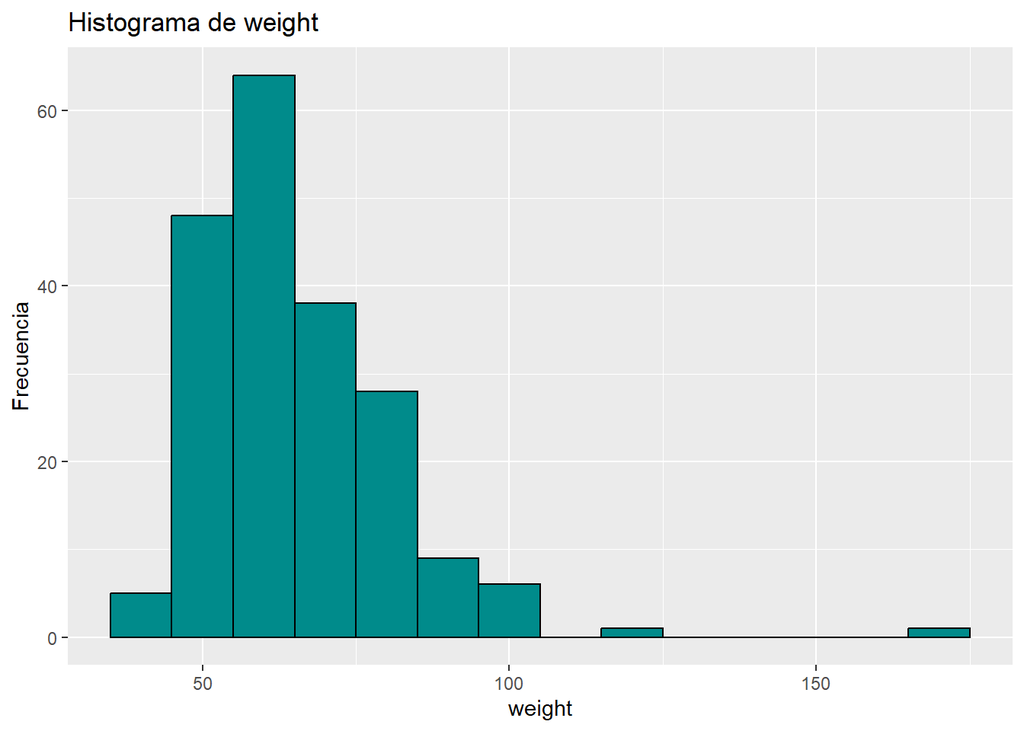

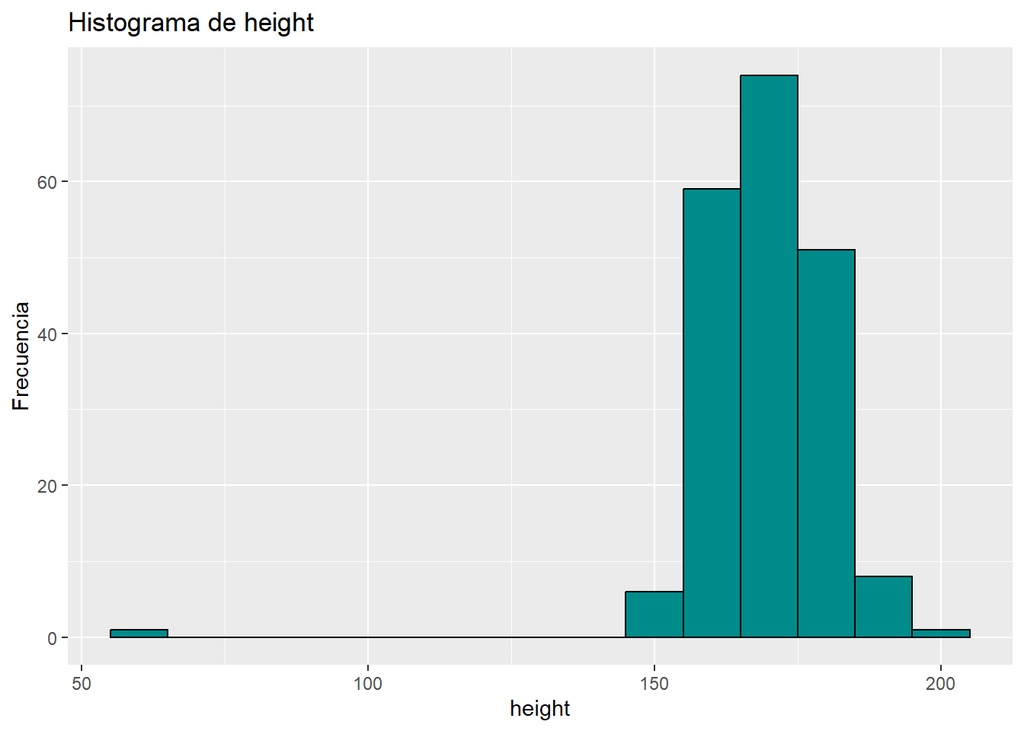

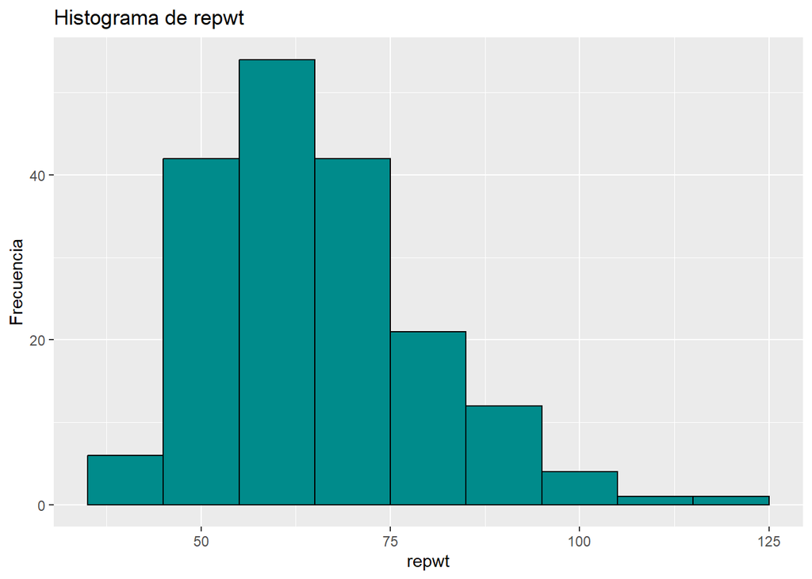

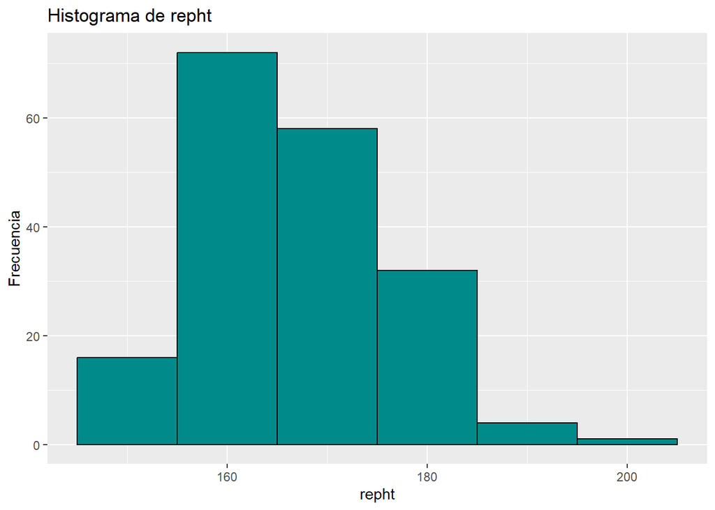

```r
data (Davis)
data = Davis

#Definir la función necesaria

histograma <- function (df) {
  columnas_numericas <- sapply (df, is.numeric)
  for (nombre_columna in names (df) [columnas_numericas]) {
    p <- ggplot(df, aes_string(nombre_columna)) +
      geom_histogram(binwidth = 10, fill = "darkcyan", color = "black") +
      labs(title = paste ("Histograma de", nombre_columna),
           x = nombre_columna,
           y = "Frecuencia")
    print(p)
    }
}
  histograma(data)
```